# Hockey Teams in Pennsylvania

Macy Trout

2024-12-01

This project maps the locations and arena capacities of Pennsylvania’s professional hockey teams, including the NHL’s Flyers and Penguins and the AHL’s Phantoms, Bears, and Wilkes-Barre/Scranton Penguins. The design incorporates hockey-inspired elements like icy blue tones, star-shaped markers, and a minimalist layout to reflect the sport’s theme.

Map Description and Design Considerations

Map 1: Hockey Team Locations

- Point Representation: Stars sized by arena capacity to reflect audience potential.
- Labels: Simple and clear, positioned to avoid crowding.

Reflection

This map effectively visualizes Pennsylvania’s hockey teams, balancing aesthetics and analysis. Arena capacities provide context beyond geography, while the clean design and cool tones align with hockey’s visual identity.

```r
library(ggplot2)
library(sf)
library(rnaturalearth)
library(rnaturalearthdata)

teams <- data.frame(
  Team = c("Philadelphia Flyers", "Pittsburgh Penguins",
           "Wilkes-Barre/Scranton Penguins", "Lehigh Valley Phantoms"),
  League = c("NHL", "NHL", "AHL", "AHL"),
  City = c("Philadelphia", "Pittsburgh", "Wilkes-Barre", "Allentown"),
  Longitude = c(-75.172, -80.005, -75.880, -75.490),
  Latitude = c(39.950, 40.440, 41.245, 40.611)
)


teams_sf <- st_as_sf(teams, coords = c("Longitude", "Latitude"), crs = 4326)
```

```r
library(devtools)
library(rnaturalearthhires)
library(rnaturalearth)
library(sf)


usa <- ne_states(country = "United States of America", returnclass = "sf")


library(dplyr)


pennsylvania <- usa %>% filter(name == "Pennsylvania")
```

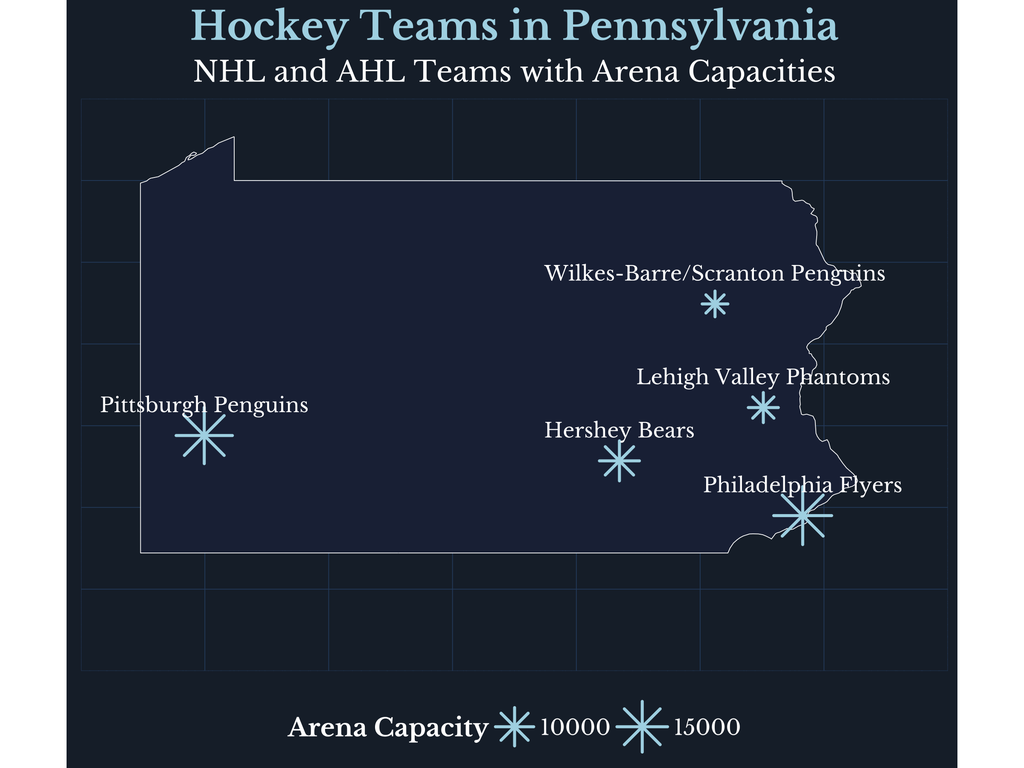

```r
library(ggplot2)
library(sf)
library(showtext)

font_add_google("Libre Baskerville", "libre_baskerville")
showtext_auto()

teams <- data.frame(
  Team = c("Philadelphia Flyers", "Pittsburgh Penguins",
           "Wilkes-Barre/Scranton Penguins", "Lehigh Valley Phantoms", "Hershey Bears"),
  League = c("NHL", "NHL", "AHL", "AHL", "AHL"),
  Longitude = c(-75.172, -80.005, -75.880, -75.490, -76.652),
  Latitude = c(39.950, 40.440, 41.245, 40.611, 40.285),
  Capacity = c(19500, 18387, 8300, 8500, 10500)
)

ggplot() +
  geom_sf(data = pennsylvania, fill = "#202A44", color = "white", size = 0.8) +
  geom_point(data = teams, aes(x = Longitude, y = Latitude, size = Capacity),
             shape = 8, fill = "white", color = "#ADD8E6", stroke = 1.2) +
  geom_text(data = teams, aes(x = Longitude, y = Latitude, label = Team),
            vjust = -1.5, size = 4, family = "libre_baskerville", color = "white") +
  scale_size_continuous(range = c(4, 10), breaks = c(8000, 10000, 15000, 20000),
                        name = "Arena Capacity") +
  coord_sf(xlim = c(-81, -74), ylim = c(39, 42.5), expand = FALSE) +
  theme_minimal() +
  theme(
    plot.background = element_rect(fill = "#1B2735", color = NA),
    panel.background = element_blank(),
    plot.title = element_text(size = 22, face = "bold", hjust = 0.5, family = "libre_baskerville", color = "#ADD8E6"),
    plot.subtitle = element_text(size = 16, hjust = 0.5, family = "libre_baskerville", color = "white"),
    legend.position = "bottom",
    legend.title = element_text(size = 14, face = "bold", family = "libre_baskerville", color = "white"),
    legend.text = element_text(size = 12, family = "libre_baskerville", color = "white"),
    axis.text = element_blank(),
    axis.title = element_blank(),
    axis.ticks = element_blank(),
    panel.grid = element_line(color = "#2E4C6D", size = 0.2)
  ) +
  labs(
    title = "Hockey Teams in Pennsylvania",
    subtitle = "NHL and AHL Teams with Arena Capacities",
    size = "Arena Capacity"
  )
```